# Single-Cell RNA-seq Analysis in R — Full Pipeline

Mouse skin aging (GSE336400) · Sessions 1–5

Chang, Nai-Wen

2026-08-13

> **How to use this file · 使用方式**
> 1. Open in RStudio. Edit only the **EDIT HERE** chunk in section 1. 只改第 1 節的 EDIT HERE 區塊。
> 2. Click **Knit** (or run chunks top-to-bottom). 按 Knit，或由上往下逐塊執行。
> 3. You get one self-contained **HTML report** with every plot. 你會得到一份含所有圖表的 HTML 報告。

> Each `install.packages` / `BiocManager::install` line only needs to run **once** — after installing, set `eval=FALSE` or comment them out. 安裝指令只要跑一次。

# 1 Setup — packages & paths · 套件與路徑

## 1.1 Install once · 安裝（只做一次）

```r
# CRAN 套件 CRAN packages
install.packages(c("Seurat", "tidyverse", "harmony", "patchwork",
                   "BiocManager", "enrichR", "ggrepel"))

# Bioconductor 套件 Bioconductor packages
BiocManager::install(c("scDblFinder", "SingleCellExperiment",
                       "SingleR", "celldex", "DESeq2"))
```

## 1.2 Load every session · 每次都要載入

```r
library(Seurat)                 # 單細胞主套件 core toolkit
library(tidyverse)              # 資料整理 + ggplot2 data wrangling + plots
library(harmony)                # 批次整合 batch integration
library(patchwork)              # 圖表拼接 combine plots
library(scDblFinder)            # 去雙細胞 doublet detection
library(SingleCellExperiment)   # SCE 物件 SCE class
library(SingleR)                # 自動註解 automated annotation
library(celldex)                # 參考資料庫 reference datasets
library(enrichR)                # 功能富集 (ORA) functional enrichment
set.seed(123)                   # 讓有隨機性的步驟可重現 reproducibility
```

## 1.3 EDIT HERE · 只改這一塊

```r
# ---- 你的六個樣本資料夾（含 barcodes/features/matrix 三件組）----
# ---- your six sample folders (each holds the 10x triplet) ----
sample_dirs <- c(
  "GSE336400_RAW/8wk_ctrl",  "GSE336400_RAW/8wk_Apo",
  "GSE336400_RAW/26wk_ctrl", "GSE336400_RAW/26wk_Apo",
  "GSE336400_RAW/52wk_ctrl", "GSE336400_RAW/52wk_Apo")

# ---- 每個路徑對應一個短名稱（順序要一致）----
# ---- one short name per path, in the SAME order ----
sample_names <- c("8wk_ctrl", "8wk_Apo",
                  "26wk_ctrl", "26wk_Apo",
                  "52wk_ctrl", "52wk_Apo")

stopifnot(length(sample_dirs) == length(sample_names))  # 兩者要一樣長 must match

# 老鼠粒線體基因用小寫 "^mt-"（人類是 "^MT-"）
# mouse mito genes are lowercase "^mt-" (human = "^MT-")
mt_pattern <- "^mt-"

# 輸出資料夾 output folder for cleaned .rds
dir.create("rds", showWarnings = FALSE)
```

# 2 Session 2 — Clean each sample · 清理每個樣本

We wrap Steps 1–5 (load → QC → doublets → normalize → scale) into one function, then loop over all six samples, saving one `.rds` each. 把五步驟包成一個函式，跑完六個樣本，各存一個 `.rds`。

```r
process_sample <- function(path, name, mt_pattern = "^mt-") {
  seu <- CreateSeuratObject(                       # 1) 讀入三件組 load triplet
    counts = Read10X(path),
    project = name, min.cells = 3, min.features = 200)

  seu[["percent.mt"]] <- PercentageFeatureSet(seu, pattern = mt_pattern)  # 2) 算粒線體% mito%

  seu <- subset(seu, subset = nFeature_RNA > 200 &  # 3) QC 過濾 filter cells
                             nFeature_RNA < 6000 &
                             percent.mt   < 15)

  sce <- as.SingleCellExperiment(seu)              # 4) 去雙細胞 doublet removal
  sce <- scDblFinder(sce)
  seu$scDblFinder.class <- sce$scDblFinder.class
  seu <- subset(seu, subset = scDblFinder.class == "singlet")

  seu <- NormalizeData(seu) |>                     # 5) 正規化 + 挑 HVG + 縮放
         FindVariableFeatures() |>
         ScaleData()
  seu
}
```

```r
# 一次跑完六個樣本，各存一個 .rds · process all six, save one .rds each
for (i in seq_along(sample_dirs)) {
  message("Processing ", sample_names[i])
  seu <- process_sample(sample_dirs[i], sample_names[i], mt_pattern)
  saveRDS(seu, file.path("rds", paste0(sample_names[i], "_clean.rds")))
}
```

> **QC snapshot of one sample · 單一樣本 QC 圖** 這裡示範最後一個樣本的 QC 分布，讓報告裡看得到過濾後的品質。

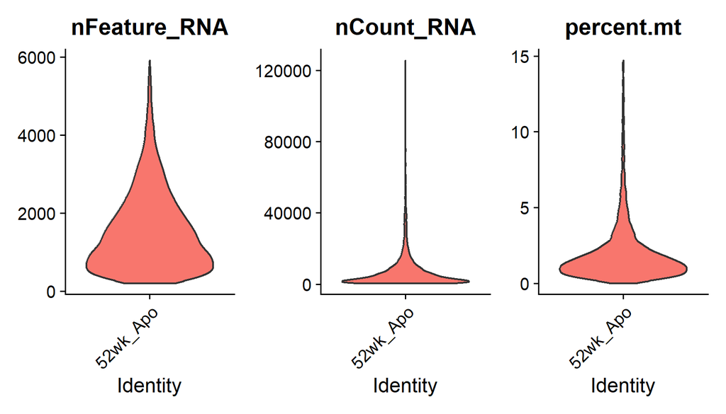

```r
VlnPlot(seu, c("nFeature_RNA", "nCount_RNA", "percent.mt"),
        ncol = 3, pt.size = 0)
```

# 3 Session 3 — Integrate, cluster, annotate · 整合、分群、註解

## 3.1 Load + merge · 讀回並合併

```r
files <- list.files("rds", pattern = "_clean.rds$", full.names = TRUE)  # 列出六個 .rds
obj_list <- lapply(files, readRDS)                                      # 逐個讀入
names(obj_list) <- sub("_clean.rds$", "", basename(files))              # 用檔名當名稱

sc_integrated <- merge(obj_list[[1]], obj_list[-1],                     # 合併成一個物件
                       add.cell.ids = names(obj_list))
sc_integrated$sample <- sub("_[^_]+$", "", colnames(sc_integrated))     # 樣本 8wk_ctrl ...
sc_integrated$age    <- sub("_.*", "", sc_integrated$sample)            # 年齡 8wk/26wk/52wk
sc_integrated$geno   <- sub(".*_", "", sc_integrated$sample)            # 基因型 Apo/ctrl
sc_integrated
```

```
## An object of class Seurat
## 18836 features across 32850 samples within 1 assay
## Active assay: RNA (18836 features, 2000 variable features)
##  18 layers present: counts.26wk_Apo, counts.26wk_ctrl, counts.52wk_Apo, counts.52wk_ctrl, counts.8wk_Apo, counts.8wk_ctrl, data.26wk_Apo, scale.data.26wk_Apo, data.26wk_ctrl, scale.data.26wk_ctrl, data.52wk_Apo, scale.data.52wk_Apo, data.52wk_ctrl, scale.data.52wk_ctrl, data.8wk_Apo, scale.data.8…
```

## 3.2 Harmony integration · 整合去批次

```r
sc_integrated <- NormalizeData(sc_integrated) |>   # 標準前處理 standard preprocessing
                 FindVariableFeatures() |>
                 ScaleData() |>
                 RunPCA()
sc_integrated <- RunHarmony(sc_integrated, group.by.vars = "sample")   # 按樣本去批次
```

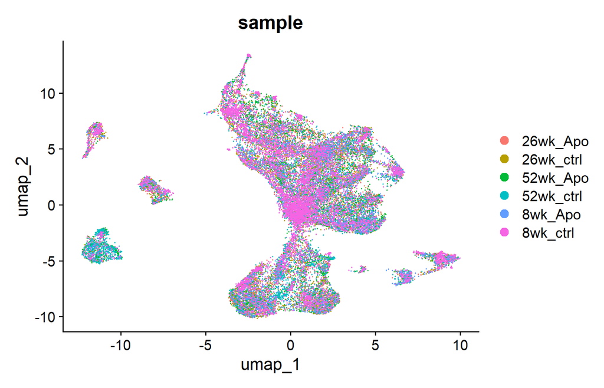

```r
# 整合前 vs 整合後：用樣本上色看批次是否混合
sc_integrated <- RunUMAP(sc_integrated, reduction = "harmony", dims = 1:30)
DimPlot(sc_integrated, group.by = "sample")        # 依樣本上色 by sample (should be mixed)
```

## 3.3 Cluster · 分群

```r
sc_integrated <- FindNeighbors(sc_integrated, reduction = "harmony", dims = 1:30)  # 鄰居圖
sc_integrated <- FindClusters(sc_integrated, resolution = 0.5)                     # 切分群
```

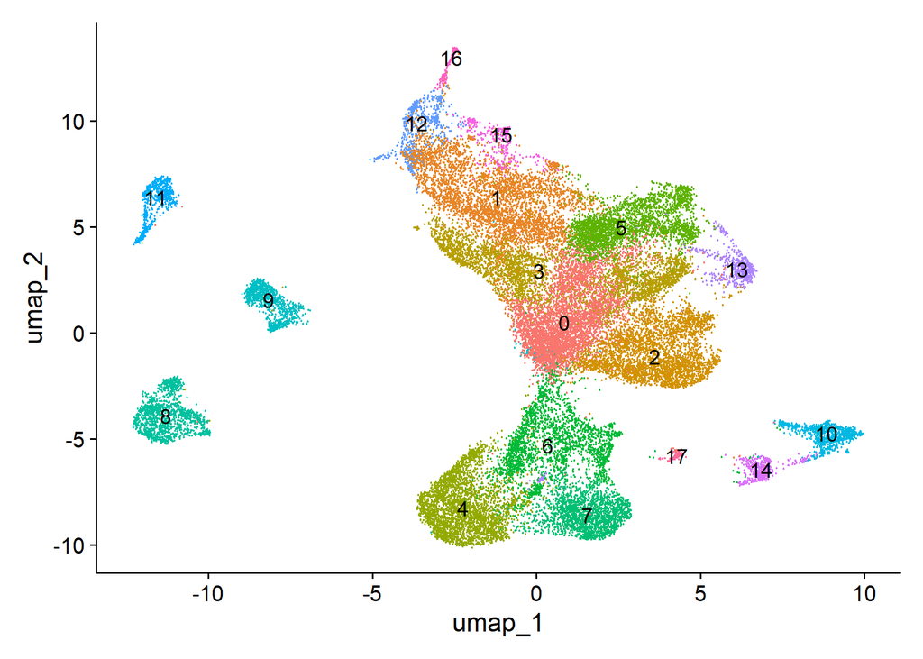

```r
DimPlot(sc_integrated, label = TRUE) + NoLegend()  # 依分群上色 by cluster
```